# Overview

**import Matplotlib:**

```python
import matplotlib.pyplot as plt
```

### init:

```
[]
```

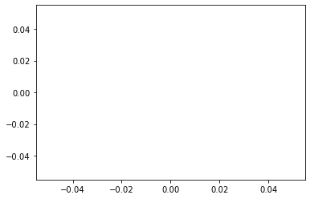

```python
plt.plot()
```

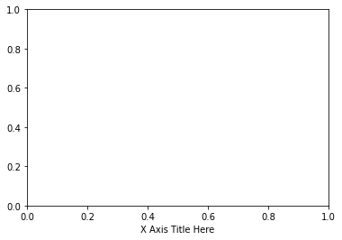

```python
plt.xlabel('X Axis Title Here')
```

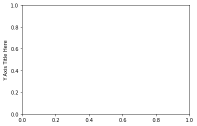

```python
plt.ylabel('Y Axis Title Here')
```

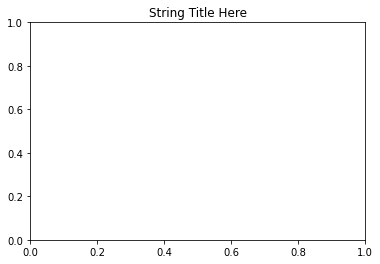

```python
plt.title('String Title Here')
```

### Basic Example

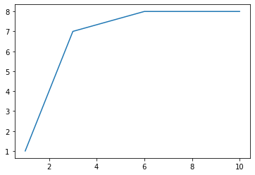

```python
plt.plot( [1, 2, 3, 6, 10], [1, 4, 7, 8, 8])
```

Một vài tham số về định dạng:

- tham số màu : **r - red**, **g -green**, **b - blue**, **y - yellow**, …
- định dạng đường : **- (đường thẳng)**, **-- (đường nét đứt)**, nếu không truyền tham số là không vẽ đường.
- định dạng đỉnh : * **(đỉnh hình bông tuyết)**, **D (đỉnh hình thoi)**, **s (đỉnh hình vuông)**, **go (chấm tròn)**, ...

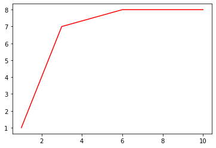

```python
plt.plot( [1, 2, 3, 6, 10], [1, 4, 7, 8, 8], 'r')
```

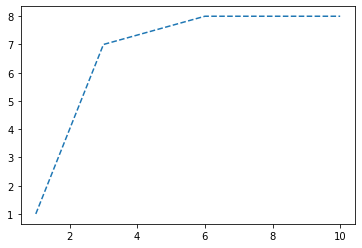

```python
plt.plot( [1, 2, 3, 6, 10], [1, 4, 7, 8, 8], '--')
```

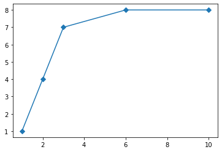

```python
plt.plot( [1, 2, 3, 6, 10], [1, 4, 7, 8, 8], '-D')
```

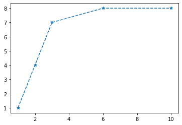

```python
plt.plot( [1, 2, 3, 6, 10], [1, 4, 7, 8, 8], '--*')
```

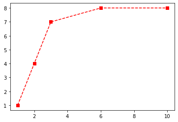

```python
plt.plot( [1, 2, 3, 6, 10], [1, 4, 7, 8, 8], '--sr')
```

## Basic Matplotlib Commands

**The data we want to plot:**

```python
import numpy as np
x = np.linspace(0, 5, 11)
y = x ** 3 + 1
```

```python
x
```

```
array([0. , 0.5, 1. , 1.5, 2. , 2.5, 3. , 3.5, 4. , 4.5, 5. ])
```

```python
y
```

```
array([  1.   ,   1.125,   2.   ,   4.375,   9.   ,  16.625,  28.   ,
        43.875,  65.   ,  92.125, 126.   ])
```

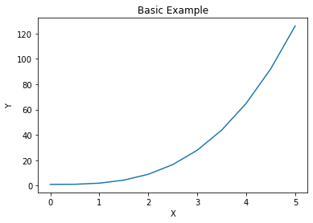

```python
plt.plot(x, y)
plt.xlabel('X')
plt.ylabel('Y')
plt.title('Basic Example')
# plt.show()
```

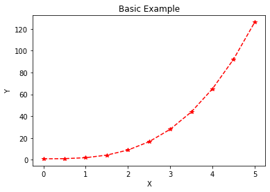

```python
plt.plot(x, y, 'r*--')
plt.xlabel('X')
plt.ylabel('Y')
plt.title('Basic Example')
plt.show()  # it like you are Printing a plot
```

### Creating Multiplots on Same Canvas

*(Vẽ hai biểu đồ cạnh nhau)*

`plt.subplot(nrows, ncols, plot_number)`

Đầu tiên ta sử dụng phương thức **subplots()** để tạo ra 2 biểu đồ. Sử dụng **subplots()** các đối tượng **Axes** sẽ được trả về.

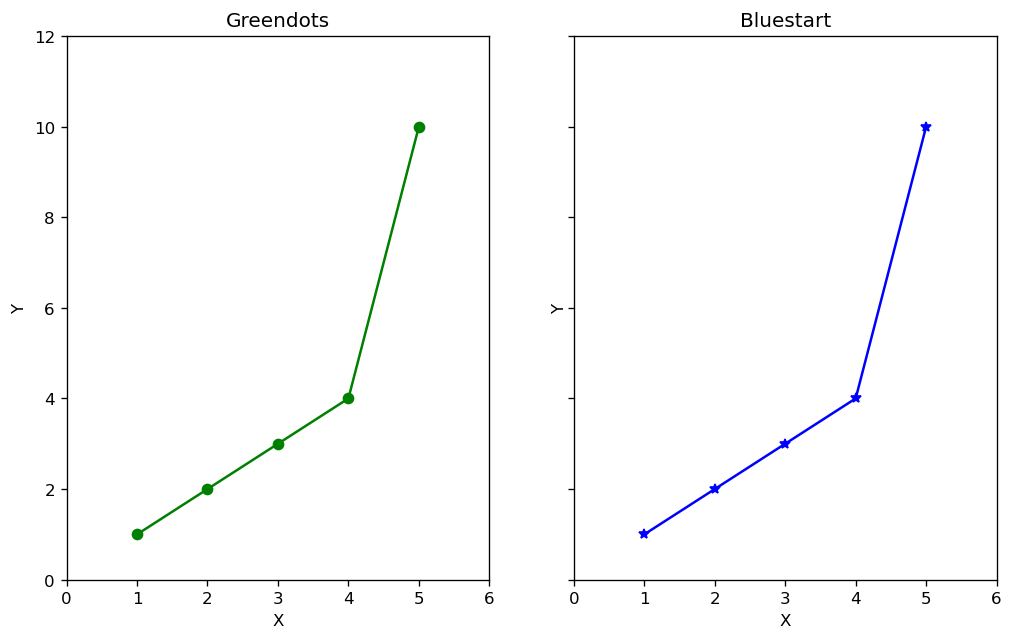

```python
fig, (ax1, ax2) = plt.subplots(1, 2, figsize = (10, 6), sharey = True, dpi = 120)

ax1.plot([1, 2, 3, 4, 5], [1, 2, 3, 4, 10], '-go') # Greendots
ax2.plot([1, 2, 3, 4, 5], [1, 2, 3, 4, 10], '-b*') # Bluestart

ax1.set(title = 'Greendots', xlabel = 'X', ylabel = 'Y', xlim = (0, 6), ylim = (0, 12))
ax2.set(title = 'Bluestart', xlabel = 'X', ylabel = 'Y', xlim = (0, 6), ylim = (0, 12))

plt.show()
```

**Tham số (1,2)** trong hàm **subplots** có thể hiểu là "một hàng, hai cột" - tương ứng bạn sẽ vẽ ra 2 biểu đồ cạnh nhau. Nếu chẳng hạn bạn thay (1,2) bằng (2,2), bạn sẽ được 4 biểu đồ.

Tham số **dpi** là độ phân giải của hình vẽ.

**Biểu đồ khác:**

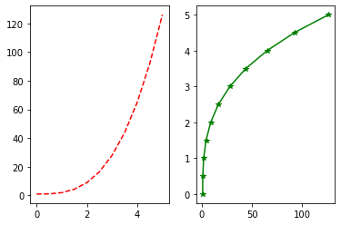

```python
plt.subplot(1,2,1)
plt.plot(x, y, 'r--') # More on color options later
plt.subplot(1,2,2)
plt.plot(y, x, 'g*-');
```

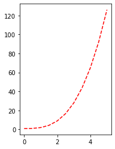

```python
plt.subplot(1,2,2)
plt.plot(x, y, 'r--') # More on color options later
```

### Creating Multi-Objects on Same Plot

**(Vẽ nhiều đối tượng cùng một biểu đồ)**

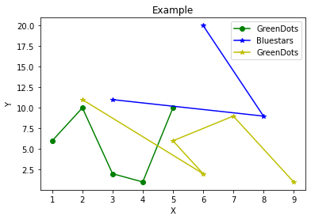

```python
plt.plot([1, 2, 3, 4, 5], [6, 10, 2, 1, 10], 'go-', label = 'GreenDots')
plt.plot([3, 8, 6], [11, 9, 20], 'b*-', label = 'Bluestars')
plt.plot([2, 6, 5, 7, 9], [11, 2, 6, 9, 1], 'y*-', label = 'GreenDots')
plt.title('Example')
plt.xlabel('X')
plt.ylabel('Y')
plt.legend(loc = 'best') # thêm chú thích
# plt.show()
```

- tham số label trong hàm **plt.plot()** là để đặt tên cho một điểm, tên này sẽ xuất hiện trong chú thích.
- **plt.xlabel** hay **plt.ylabel** là để đặt tên cho trục x và trục y.
- **plt.title** là để đặt tên cho biểu đồ
- **plt.legend** sẽ đi tìm các thành phần chứa tham số label và đưa vào chú thích